# CS156 - Assignment 3

## Armin Hamp

The .ipynb version of this notebook is available at: https://gist.github.com/hamparmin/117626f56934d22466843e50fd9746c1

```python
'''
Import Libraries
'''
#data processing
import pandas as pd
import numpy as np
import datetime

#plotting
import matplotlib.pyplot as plt
import matplotlib.cm as cm

#rbf transform and regression model
from sklearn import linear_model
from sklearn import metrics
from sklearn.metrics.pairwise import rbf_kernel
from sklearn.linear_model import Ridge
```

## Pre-processing

In this section I import the data, turn the date-time variable into two separate variables, measuring the day of the year and time of the day in integers respectively. This is because we assume that there is some cyclical relationship between time/date and temperature on a daily/yearly basis.

```python
'''
Loading data and pre-processing.
'''
years = range(2011, 2017)

files = ['CRNS0101-05-%d-CA_Yosemite_Village_12_W.txt' % y for y in years]
usecols = [1, 2, 8]

data = [np.loadtxt(f, usecols=usecols) for f in files]
data = np.vstack(data)

#map from HHmm to an integer representing minute of day
data[:, 1] = np.floor_divide(data[:, 1], 100) * 60 + np.mod(data[:, 1], 100)

#filtering for invalid data
valid = data[:, 2] > -1000

#map from YYYYMMDD to an integer representing day of year
data_days = list(map((lambda y: datetime.datetime.strptime(str(y), '%Y%m%d.0').timetuple().tm_yday),
                      data[valid, 0]))

#create dataframe to store all data
df=pd.DataFrame()
df["days"]=data_days
df["minutes"]=data[valid,1]
df["temp"]=data[valid,2]
df.shape
```

```
(630854, 3)
```

## Radial Basis Functions

In this section we are turning the pair of time inputs into a much richer representation, mapping (d,t) into (Φ₁(d), Φ₂(t)). In order to find out what parameters: $\sigma, \alpha $ and the number of RBF functions to use for this mapping, I experiment with different parameter values on just the training data. This can give us some estimates about good parameter values.

```python
'''
Create functions to:

1. Split data at a specified cutoff point.
2. Apply the rbf transform on data given parameter values
3. Fit a Ridge Regression model on the data and evaluate model by MSE
4. Create a center array for x_days based on n_rbf - range(0,365)
5. Create a center array for x_minutes based on n_rbf - range (0,1435)

Index 525887 stands for the split between 2015 and 2016.

'''
def split_data(df,cutoff):
    x_train=[df.days.values[:cutoff],df.minutes.values[:cutoff]]
    x_test=[df.days.values[cutoff:],df.minutes.values[cutoff:]]
    y_train=df.temp.values[:cutoff]
    y_test=df.temp.values[cutoff:]
    return (x_train,x_test,y_train,y_test)

def rbf_transform(df,cutoff,center1,center2,sigma1,sigma2,alpha):
    data=split_data(df,cutoff)
    x1=np.array(rbf_kernel(data[0][0].reshape(-1,1),center1,gamma=1/sigma1))
    x2=np.array(rbf_kernel(data[0][1].reshape(-1,1),center2,gamma=1/sigma2))
    x_train=np.concatenate((x1,x2),axis=1)

    x3=np.array(rbf_kernel(data[1][0].reshape(-1,1),center1,gamma=1/sigma1))
    x4=np.array(rbf_kernel(data[1][1].reshape(-1,1),center2,gamma=1/sigma2))
    x_test=np.concatenate((x3,x4),axis=1)

    return x_train,x_test,data[2],data[3]


def regr(df,cutoff,center1,center2,sigma1,sigma2,alpha):
    x_train,x_test,y_train,y_test=rbf_transform(df,cutoff,center1,center2,sigma1,sigma2,alpha)
    regr_rbf=linear_model.Ridge(alpha=alpha,fit_intercept=True) #model selection
    regr_rbf.fit(x_train,y_train) #model fitting
    y_pred=regr_rbf.predict(x_train) #model prediction
    MSE=metrics.mean_squared_error(y_train, y_pred) #calculate MSE train for model
    return MSE

def center1(n_rbf):
    #function to allocate centers based on different number of RBFs to be specified
    return np.linspace(0,365,n_rbf).reshape(-1,1)

def center2(n_rbf):
    #function to allocate centers based on different number of RBFs to be specified
    return np.linspace(0,1435,n_rbf).reshape(-1,1)
```

```python
'''
Estimate reasonable RBF parameter values by:
1. Creating RBF transforms with different: alphas, sigmas and n_rbf
2. Fitting a regression onto the rbf transforms.
3. Calculating and recording MSE (train MSE) for each regression.
4. Use results to find best parameter values.

Params to test:
-sigma: corresponds to the variance of RBF
-n_rbf: number of RBF functions
-alpha: regularization parameter corresponding to tightness of fit

A k-fold or LOO cross-validation would be a more rigorous way to find
the best parameter values, however, even with a single split of the
data, I have to check 3^4 models, which takes ~500 seconds to compute.

'''
cutoff=525887 #cutoff at year 2016

results=pd.DataFrame() #df for results

#specify parameter values to test
sigma1=[100,500,1000]
sigma2=[100,500,1000]
alphas=[0.01,0.05,0.1,0.5,1,5,10]
center1s=[5,50,100]
center2s=[15,100,500]

#test centers and sigmas with alpha being held constant at 0.1
MSEs,sigma1s,sigma2s,centers1,centers2=[],[],[],[],[]
for i in sigma1:
    for j in sigma2:
        for k in center1s:
            for l in center2s:
                MSEs.append(regr(df,cutoff,center1(k),center2(l),i,j,0.1))
                sigma1s.append(i)
                sigma2s.append(j)
                centers1.append(k)
                centers2.append(l)
results["sigma1"]=sigma1s
results["sigma2"]=sigma2s
results["center1"]=centers1
results["center2"]=centers2
results["MSE Training Error"]=MSEs
```

```python
#display results
print(results.to_string())
```

```
    sigma1  sigma2  center1  center2  MSE Training Error
0      100     100        5       15           49.866916
1      100     100        5      100           47.809689
2      100     100        5      500           47.809228
3      100     100       50       15           24.440743
4      100     100       50      100           22.378295
5      100     100       50      500           22.377835
6      100     100      100       15           24.076633
7      100     100      100      100           22.013743
8      100     100      100      500           22.013283
9      100     500        5       15           49.052105
10     100     500        5      100           47.809241
11     100     500        5      500           47.809237
12     100     500       50       15           23.623620
13     100     500       50      100           22.377846
```

[output cut: 67 more lines]

Our results show that MSE is best reduced by the following parameter setups:

1. $\sigma \geq 100$, which provides sufficient variance for our RBFs.
2. $n_{RBF} \geq \frac{n_{range}}{4}$, provide a sufficient number of centres for the RBF.

We will use these insights now, to find the best $\alpha$ for the regression model.

```python
#testing for alpha
results_alpha=pd.DataFrame()
results_alpha["alpha"]=alphas
results_alpha["MSE"]=[regr(df,cutoff,center1(100),center2(500),200,200,i) for i in alphas]
results_alpha
```

|  | alpha | MSE |
| --- | --- | --- |
| 0 | 0.01 | 22.343558 |
| 1 | 0.05 | 22.388826 |
| 2 | 0.10 | 22.406097 |
| 3 | 0.50 | 22.460664 |
| 4 | 1.00 | 22.490081 |
| 5 | 5.00 | 22.549994 |
| 6 | 10.00 | 22.574495 |

Our results show that $\alpha=0.01$ provides the smallest MSE. Since the seasonal/daily variation in temperature should not be an overly "curvy" function to fit for, this relatively low value for $\alpha$ is justifiable.

## Full Model

```python
'''
Linear regression model.
'''
#specify parameters
alpha=0.01
sigma1,sigma2=200,200
n_rbf1,n_rbf2=100,500
cutoff=525887

#set up model
x_train,x_test,y_train,y_test=rbf_transform(df,cutoff,center1(n_rbf1),center2(n_rbf2),sigma1,sigma2,alpha)
regr_rbf=linear_model.Ridge(alpha=alpha,fit_intercept=True) #model selection
regr_rbf.fit(x_train,y_train) #model fitting
```

```
Ridge(alpha=0.01, copy_X=True, fit_intercept=True, max_iter=None,
      normalize=False, random_state=None, solver='auto', tol=0.001)
```

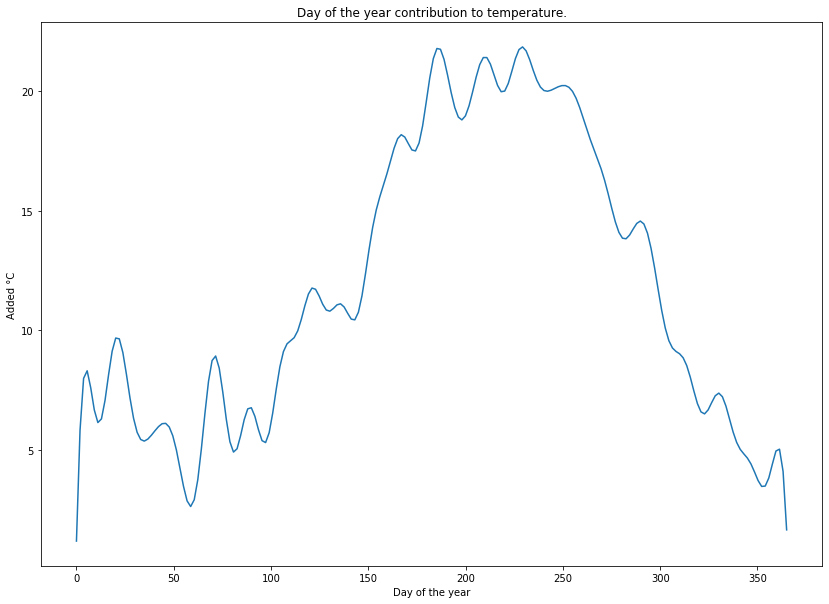

```python
'''
Evaluate day of the year contribution:
1. create an array for days of the year - range[0,365]
2. create an array of zeros for minutes (since zero contribution)
3. apply rbf transformation on the arrays
4. use model to predict temp using rbf transformed arrays
5. plot results
'''
days=np.linspace(0,365,200) #1
minutes=np.zeros((200,)) #2
days_rbf=rbf_kernel(days.reshape(-1,1),center1(n_rbf1),gamma=1/sigma1)#3
minutes_rbf=rbf_kernel(minutes.reshape(-1,1),center2(n_rbf2),gamma=1/sigma2)#3
x=np.concatenate((days_rbf,minutes_rbf),axis=1)
temp_days=regr_rbf.predict(x)#3

# 4.- plot
plt.figure(figsize=(14,10))
plt.title("Day of the year contribution to temperature.")
plt.xlabel("Day of the year")
plt.ylabel("Added °C")
plt.plot(days,temp_days)
plt.show()
```

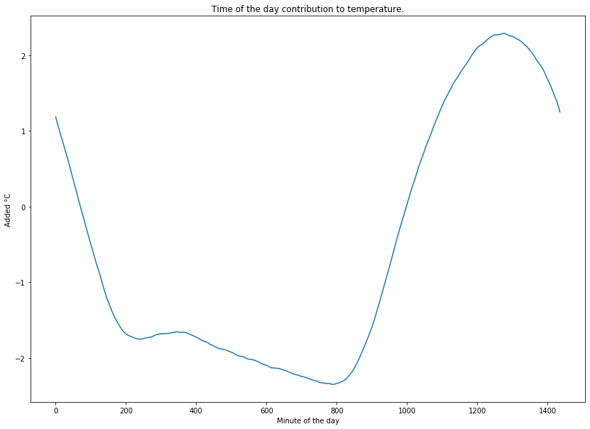

```python
'''
Evaluate time of the day contribution:
1. create an array for time of the day - range[0,1435]
2. create an array of zeros for days (since zero contribution)
3. apply rbf transformation on the arrays
4. use model to predict temp using rbf transformed arrays
5. plot results
'''
minutes=np.linspace(0,1435,200) #1
days=np.zeros((200,)) #2
days_rbf=rbf_kernel(days.reshape(-1,1),center1(n_rbf1),gamma=1/sigma1)#3
minutes_rbf=rbf_kernel(minutes.reshape(-1,1),center2(n_rbf2),gamma=1/sigma2)#3
x=np.concatenate((days_rbf,minutes_rbf),axis=1)
temp_minutes=regr_rbf.predict(x)#3

# 4.- plot
plt.figure(figsize=(14,10))
plt.title("Time of the day contribution to temperature.")
plt.xlabel("Minute of the day")
plt.ylabel("Added °C")
plt.plot(minutes,temp_minutes)
plt.show()
```

[figure not shown]

```python
'''
3D Visualization of the contribution of day of the year and time of the day.

'''
#create a distribution of data over year/day
days=np.linspace(0,365,200)
minutes=np.linspace(0,1435,200)
days_rbf=rbf_kernel(days.reshape(-1,1),center1(n_rbf1),gamma=1/sigma1)
minutes_rbf=rbf_kernel(minutes.reshape(-1,1),center2(n_rbf2),gamma=1/sigma2)

#expand data for 3d plotting
x3d=[]
for i in range(len(days_rbf)):
    for j in range(len(minutes_rbf)):
        x3d.append(np.hstack((days_rbf[i],minutes_rbf[j])))

#predict z/temp
z=regr_rbf.predict(x3d)
z=z.reshape(200,200)

#plot 3d plot
x,y=np.meshgrid(days,minutes)
z=z.reshape(200,200)
fig = plt.figure(figsize=(14,14))
ax = fig.gca(projection='3d')
ax.set_xlabel('Minute of the day')
ax.set_ylabel('Day of the year')
ax.set_zlabel('Temperature °C')
surf = ax.plot_surface(x, y, z, cmap=cm.coolwarm, linewidth=0, antialiased=False)
plt.show()
```

## Model Performance

In this section I evaluate model performance, by calculating $R^2$ values for:

1. A model trained only on days data.
2. A model trained only on minute data.
3. The full model.

```python
'''
Model only trained on days of year.
'''
data=split_data(df,cutoff)
days=np.array(rbf_kernel(data[0][0].reshape(-1,1),center1(n_rbf1),gamma=1/sigma1))
days_test=np.array(rbf_kernel(data[1][0].reshape(-1,1),center1(n_rbf1),gamma=1/sigma1))
regr_rbf=linear_model.Ridge(alpha=alpha,fit_intercept=True) #model selection
regr_rbf.fit(days,data[2]) #model fitting
r2_days=regr_rbf.score(days_test,data[3])
print("The R2 coefficient for a model only trained on days data is: R2 =",r2_days)
```

```
The R2 coefficient for a model only trained on days data is: R2 = 0.5389894498576617
```

```python
'''
Model only trained on minutes of the day.
'''
data=split_data(df,cutoff)
minutes=np.array(rbf_kernel(data[0][1].reshape(-1,1),center1(n_rbf2),gamma=1/sigma2))
minutes_test=np.array(rbf_kernel(data[1][1].reshape(-1,1),center1(n_rbf2),gamma=1/sigma2))
regr_rbf=linear_model.Ridge(alpha=alpha,fit_intercept=True) #model selection
regr_rbf.fit(minutes,data[2]) #model fitting
r2_minutes=regr_rbf.score(minutes_test,data[3])
print("The R2 coefficient for a model only trained on minutes data is: R2 =",r2_minutes)
```

```
The R2 coefficient for a model only trained on minutes data is: R2 = 0.005182683867340998
```

```python
"""
Full model.
"""
x_train,x_test,y_train,y_test=rbf_transform(df,cutoff,center1(n_rbf1),center2(n_rbf2),sigma1,sigma2,alpha)
regr_rbf=linear_model.Ridge(alpha=alpha,fit_intercept=True) #model selection
regr_rbf.fit(x_train,y_train) #model fitting
r2_full=regr_rbf.score(x_test,y_test)
print("The R2 coefficient for the full model is: R2 =",r2_full)
```

```
The R2 coefficient for the full model is: R2 = 0.5836414908914926
```

## HC Appendix

**#constraints:** In finding the appropriate parameter values for my model, I acknowledged that cross-validation would provide a more rigorous estimate for our parameters, but stressed that it would take too long to run. I worked around this constraint with my solution, which still took ~500s to run.